# Introduction to Bayesian Statistics with R

5 May 2025

## Dart throwing

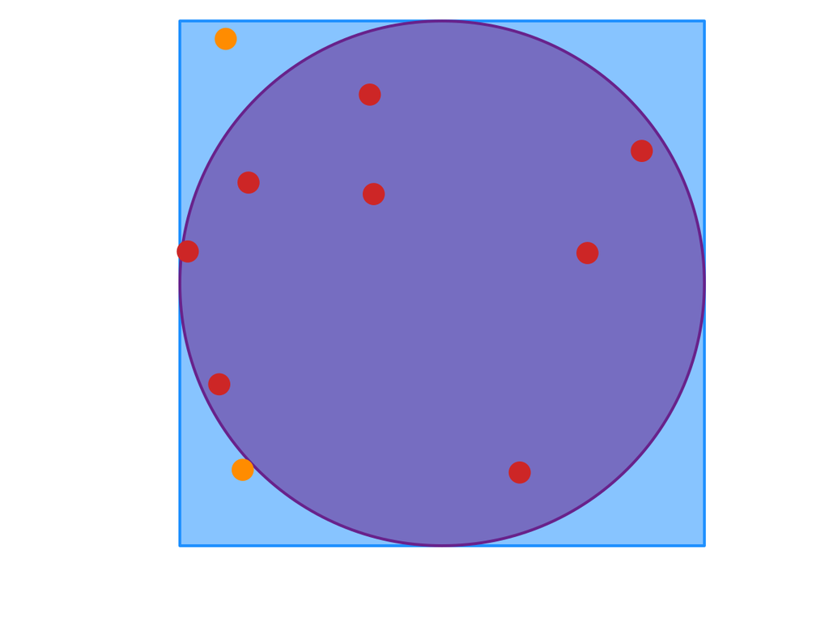

Question: what’s the probability your dart hits the dartboard?  
(given it is uniformly thrown within the square)

## Dart throwing

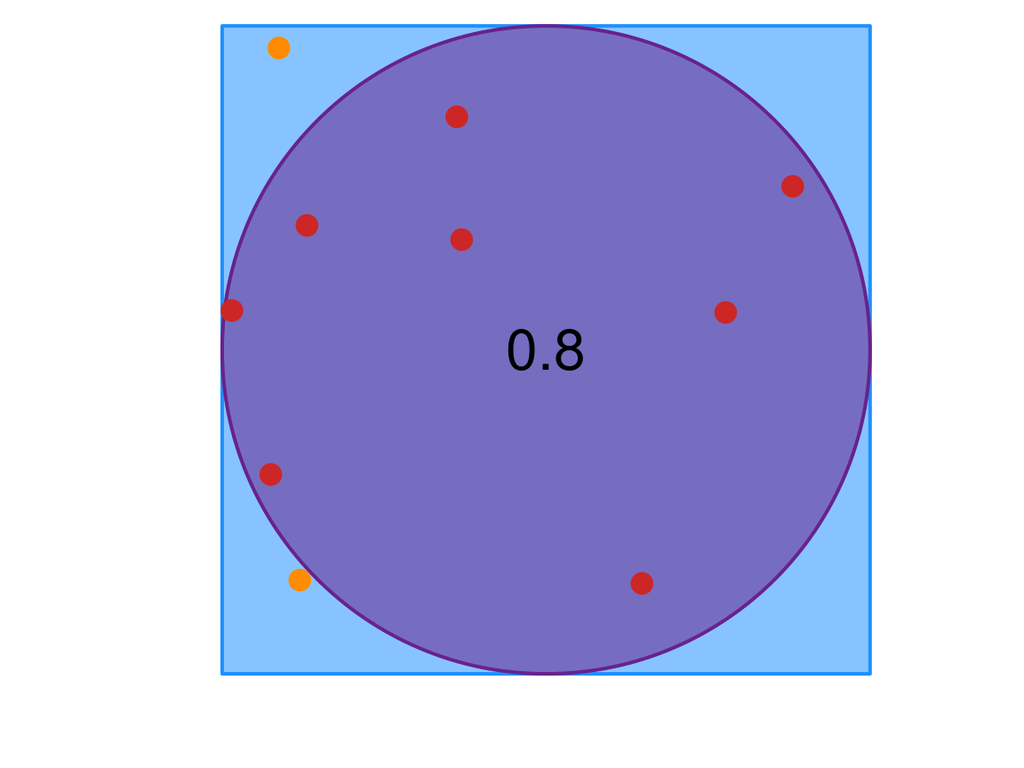

Answer: \(\frac{\pi}{4} \approx\) 0.785398 from geometry

Or we can estimate by throwing lots of darts!

## Normal samples

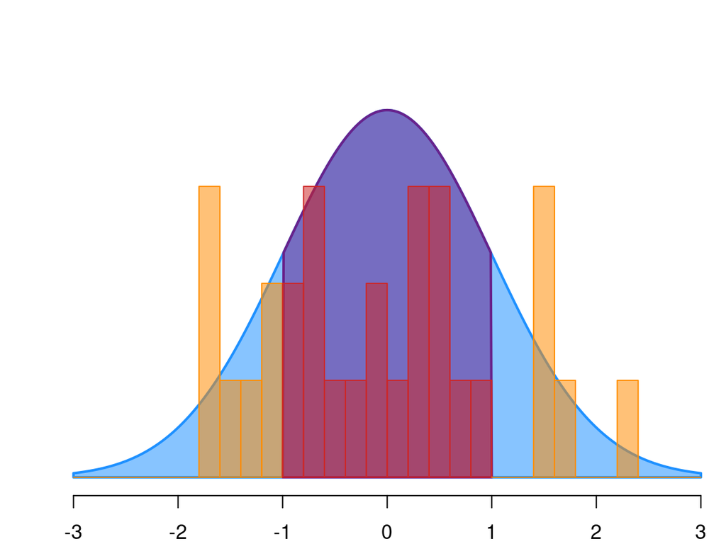

Question: what’s the probability a standard normal sample is between -1 and 1?

## Normal samples

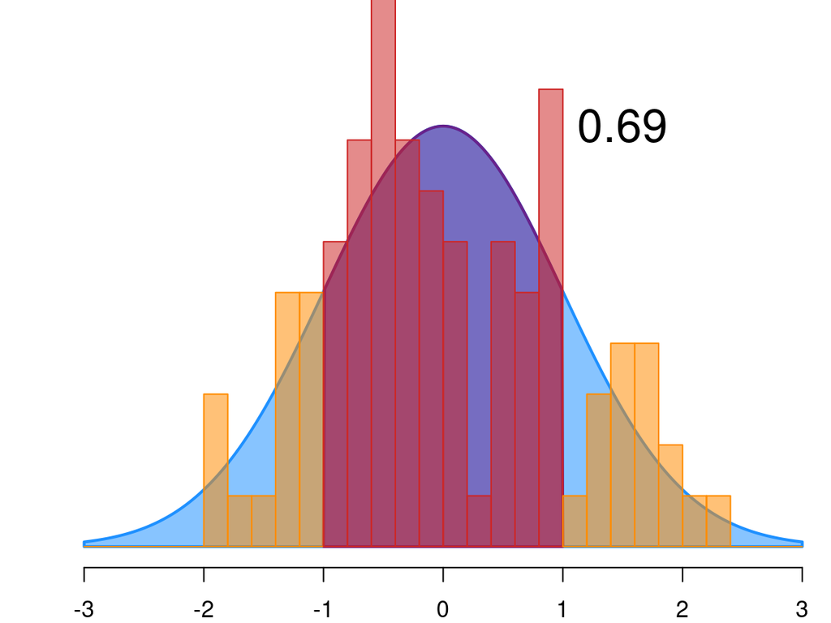

Answer: 0.682689 from calculus (next slide)

Or we can estimate from lots of random samples!

## Integration

We are actually integrating

\[\int_{-1}^{1} f(x) \mathrm{d}(x)\]

with \(f(x)\) the probability density of a standard normal

\[f(x) = \frac{1}{\sqrt{2\pi}}\mathrm{e}^{-\frac{x^2}{2}}\]

Analytical result is \(\Phi(1) - \Phi(-1)\)

- \(\Phi\) is CDF of a normal (an error function)

```r
pnorm(1) - pnorm(-1)
```

```
## [1] 0.6826895
```

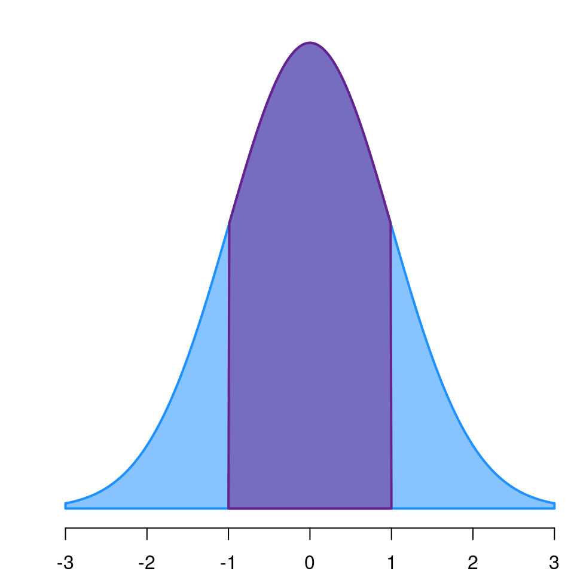

## Numerical integration

Let’s approximate the integral

\[\int_{-1}^{1} f(x) \mathrm{d}(x)\]

with lots of rectangular bins:

\[ \approx \sum_{i=1}^{B} f(x_i) \delta x\]

- \(B\) bins
- \(x_i\) are the midpoints of the bins
- \(\delta x\) is the width of the bins

Numerical result: (*cf* 0.682689)

```
## [1] 0.683498
```

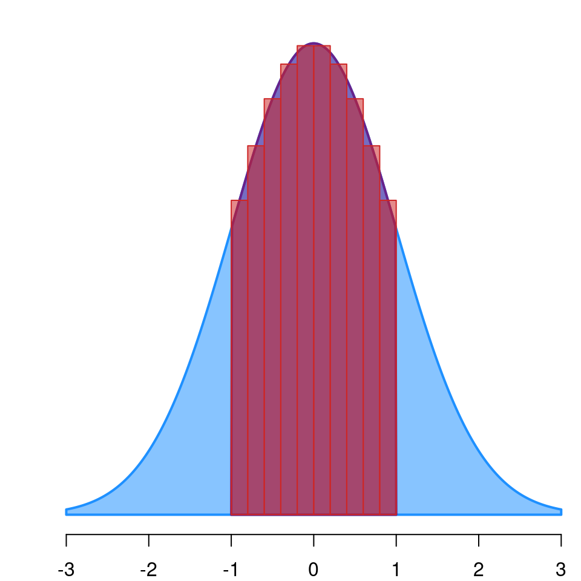

## Sampling approximation

Or we can approximate the integral

\[\int_{-1}^{1} f(x) \mathrm{d}(x)\]

with lots of normal samples:

\[ \approx \frac{1}{M}\sum_{i=1}^{M} I(-1< x_i < 1)\]

- \(M\) samples
- \(x_i\) are the samples \(\sim f(x)\)
- \(I\) is the indicator function

Numerical result: (*cf* 0.682689)

```
## [1] 0.69
```

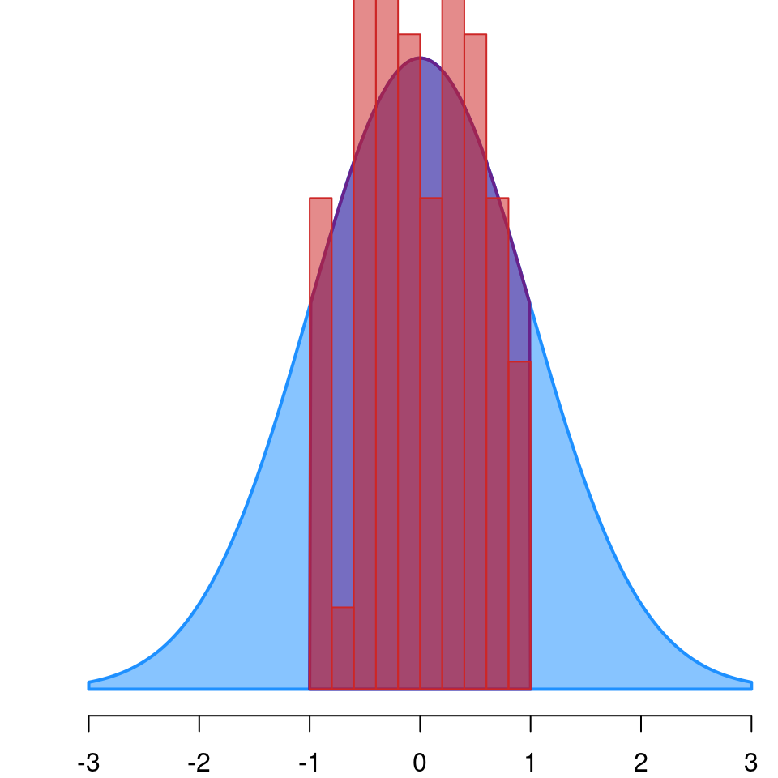

## More integration

Let’s now integrate

\[\int_{-1}^{1} x^2 f(x) \mathrm{d}(x)\] with lots of rectangular bins

\[ \approx \sum_{i=1}^{B} x_i^2 f(x_i) \delta x\]

Numerical result:

```
## [1] 0.197938
```

The analytical result is \(\Phi(1) - \Phi(-1) - 2f(1)\)

```r
pnorm(1) - pnorm(-1) - 2*dnorm(1)
```

```
## [1] 0.198748
```

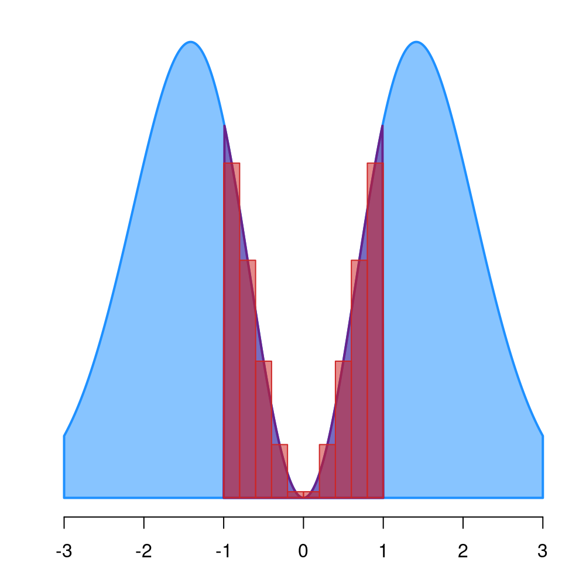

## More integration split

Let’s now integrate

\[\int_{-1}^{1} x^2 f(x) \mathrm{d}(x)\]

with lots of rectangular bins

\[ \approx \sum_{i=1}^{B} x_i^2 f(x_i) \delta x\]

Same as multiplying the bins from normal

- by \(x_i^2\) at their midpoints

\[ x_i^2 \cdot f(x_i) \delta x\]

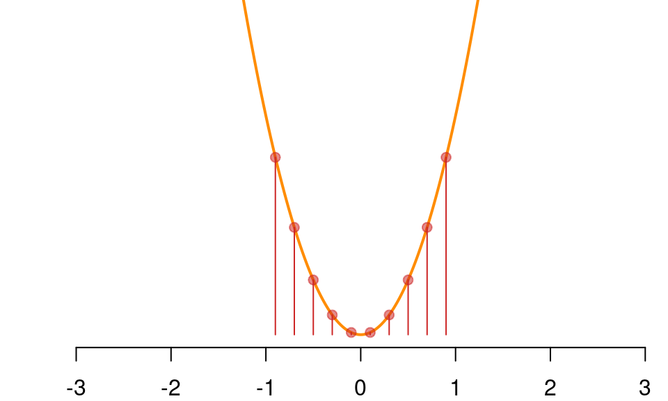

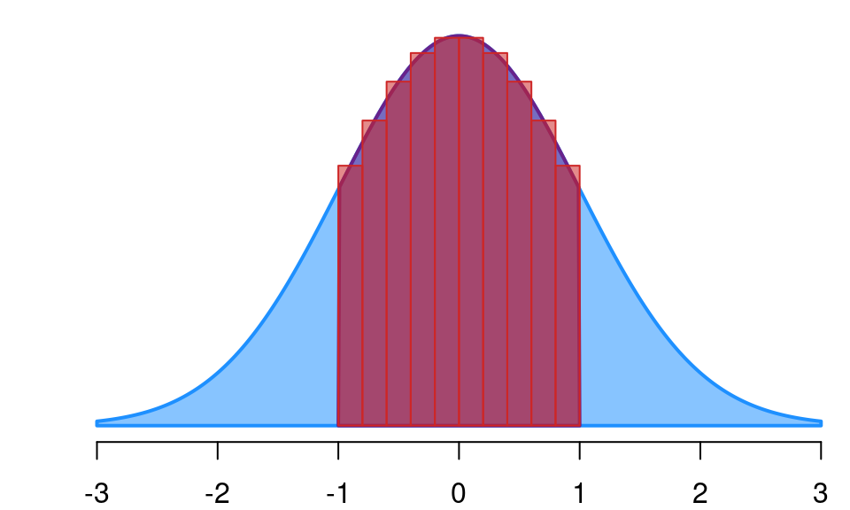

## More integration sampling

For our integral

\[\int_{-1}^{1} x^2 f(x) \mathrm{d}(x)\]

we can replace the normal bins

- with samples from the normal

\[ \approx \frac{1}{M}\sum_{i=1}^{M} x_i^2 I(-1< x_i < 1)\]

Since the \(x_i\) are sampled \(\sim f(x)\)

- we just need to average \(x^2\) over the sample

Numerical result: (*cf* 0.198748)

```
## [1] 0.208553
```

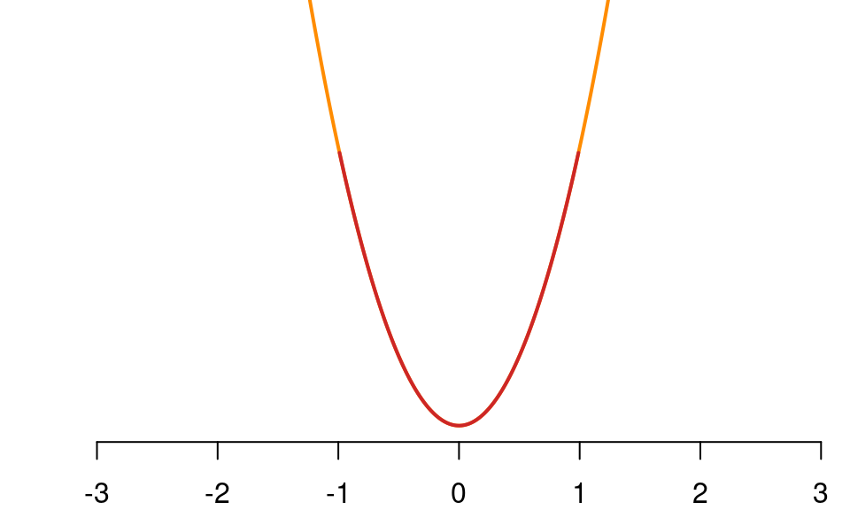

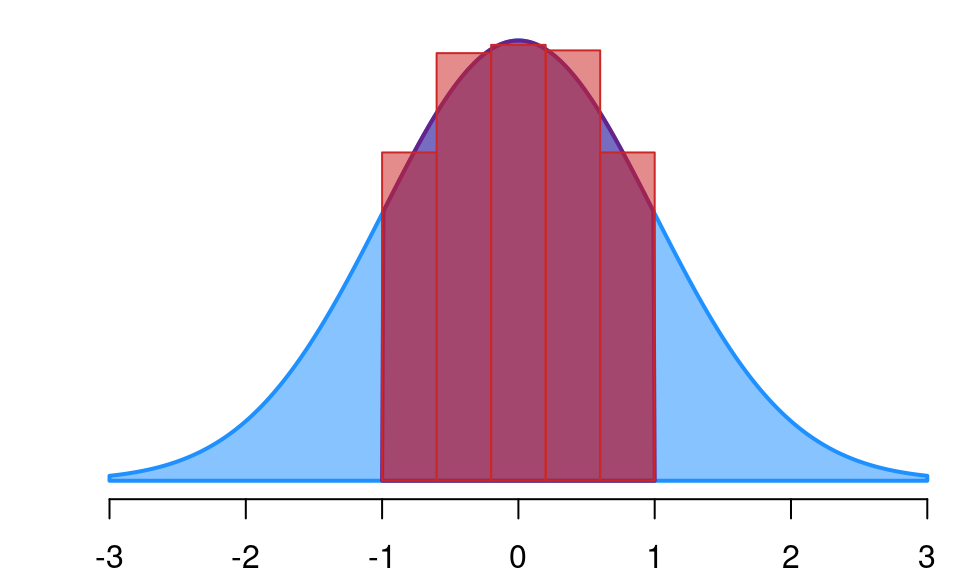

## Monte Carlo approximation

In general, these integrals are expectations

\[E[g(x)] = \int g(x) p(x) \mathrm{d} x\]

If we can sample proportionally to \(p(x)\)

- can use Monte Carlo approximation

\[E[g(x)] \approx \frac{1}{M} \sum_{i=1}^{M} g(x_i) \]

- for \(M\) random samples \(x_i\), sampled \(\sim p(x)\)

Accuracy typically scales like \(\frac{1}{\sqrt{M}}\) for any dimension

- number of bins for numerical integration grows exponentially in the dimension

Lies behind lots of Bayesian analyses

Question: how do we get samples from arbitrary distributions?

## MCMC

Markov Chain Monte Carlo (MCMC) **Metropolis, Rosenbluth**\(\times\)**2, Teller**\(\times\)**2 (1953); Hastings (1970)**

To sample proportionally to any function \(p(x)\):

[1.] From current position \(x\), propose a new position \(x'\)

\[x' = x + \delta\, , \qquad \delta \sim q(d)\]

- with a symmetric distribution \(q\)(d), *eg* a normal (can modify algorithm for asymmetric too)

[2.] Accept \(x'\) with probability

\[\min \left(1, \frac{p(x')}{p(x)}\right)\]

- and move current position to \(x'\)
- otherwise stay at \(x\)

[3.] Repeat, that’s all!

- (though it may take many iterations to converge)

## MCMC example

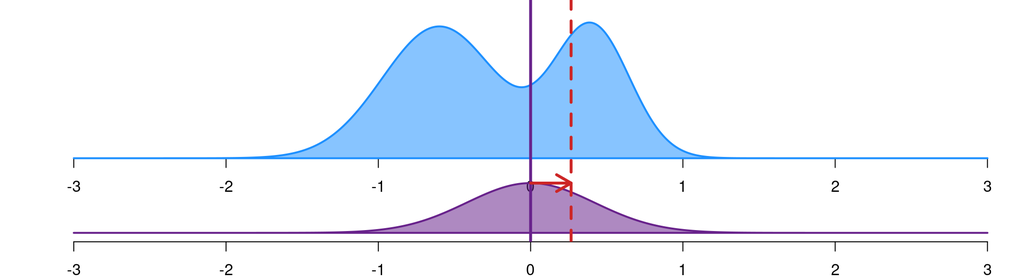

```
## [1] "Current x: 0"
```

```
## [1] "Proposed x: 0.265811"
```

```
## [1] "Acceptance probability: 1"
```

```
## [1] "Move was accepted."
```

## MCMC example 2

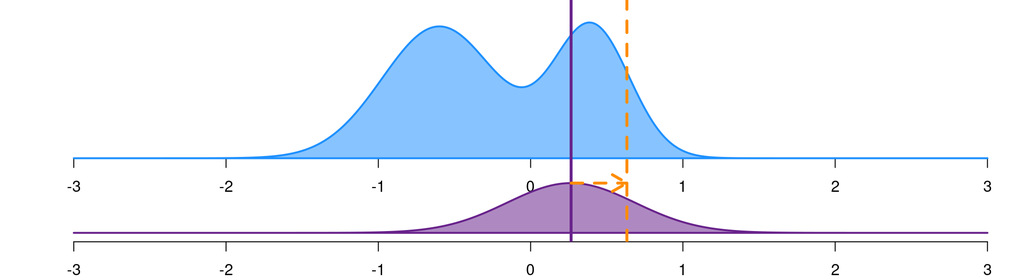

```
## [1] "Current x: 0.265811"
```

```
## [1] "Proposed x: 0.63231"
```

```
## [1] "Acceptance probability: 0.699042"
```

```
## [1] "Move was rejected."
```

## MCMC samples

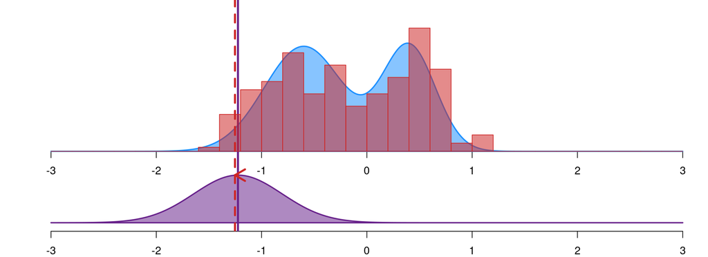

## HMC

Hamiltonian Monte Carlo (HMC) **Duane, Kennedy, Pendleton and Roweth (1987); Neal (1995, 2011)**

To sample proportionally to any function \(p(x)\): add a new dimension \(\rho\)!

Make \(\rho\) Gaussian, and define the negative log-likelihood as an energy surface \[H(x,\rho) = -\log\{p(x)\} + \frac{\rho^2}{2}\]

[1.] From current position \(x\), sample a Gaussian \(\rho\) and propose a new pair \((x', \rho')\) by propagating (numerically) under the (energy-preserving) Hamiltonian dynamics: \(\frac{\mathrm{d}x}{\mathrm{d}t} = \frac{\partial H}{\partial \rho}, \, \frac{\mathrm{d}\rho}{\mathrm{d}t} = -\frac{\partial H}{\partial x}\)

[2.] Accept \(x'\) with probability

\[\min \left(1, \exp\{H(x,\rho) - H(x', \rho')\}\right) \approx 1\]

- and move current position to \(x'\)
- otherwise stay at \(x\)

[3.] Repeat, that’s all!

## HMC example

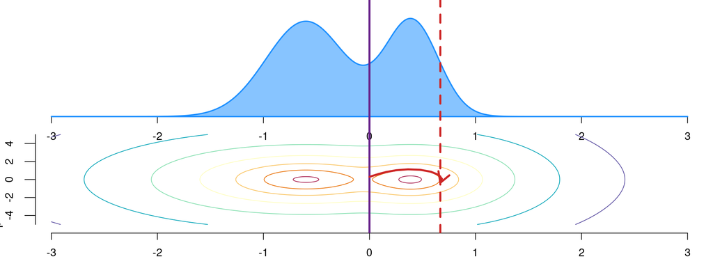

## HMC samples

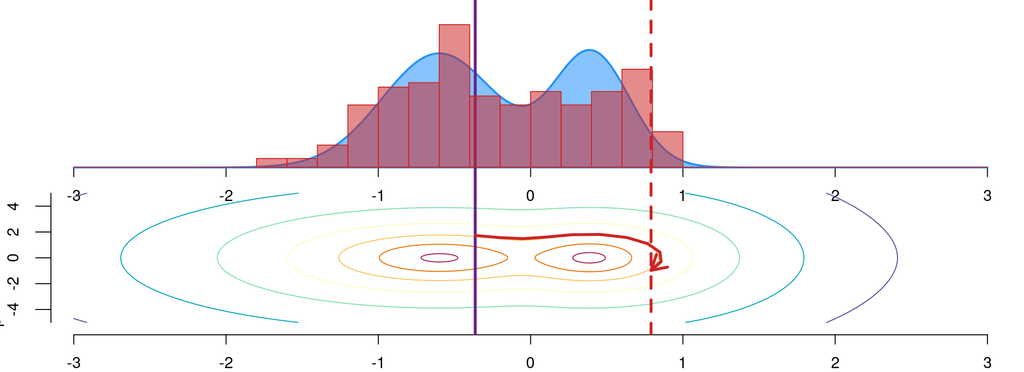

## Summary

With random samples can obtain Monte Carlo estimates

- to expectations and integrals

Behind the scenes in most Bayesian analyses

To obtain random samples estimates

- can use Markov Chain Monte Carlo (MCMC)

Start of chain correlated with initial point

- often remove initial burn-in iterations

Faster, more computationally efficient schemes

- Hamiltonian Monte Carlo (HMC)

\(\rightarrow\) Exercises 3